# SEM Workshop 02

# 臨床心理学のための共分散構造分析 (SEM)ワークショップ

## 第2部：jamovi環境構築 ＆ 実践ハンズオン

ここからは実際にPCを操作します。 実機操作では，統計解析パッケージ `lavaan` に標準搭載されている，有名な SEM 用のオープンデータ `PoliticalDemocracy` を使用します。

- PoliticalDemocracy のダウンロード

### 1. 環境構築とデータの読み込み

#### Step 1: SEMLj モジュールのインストール

1. jamoviを起動し，右上の「＋ (モジュール)」ボタンをクリックして「jamovi ライブラリ」を開きます。
2. 検索窓に `SEMLj` と入力し，表示されたモジュールの「Install」をクリックしてください。数秒で上部リボンメニューに「SEM」というアイコンが登場します。

Fig.4 SEMLj

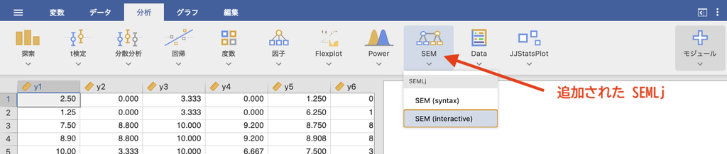

#### Step 2: サンプルデータを開く

1. jamoviの左上にあるメニューアイコン (横三本線)をクリックし，「開く」 $\rightarrow$ 「このPC」 を選択します。
2. あらかじめ配布された PoliticalDemocracy データを開きます。
3. 画面に `x1` から `x3`, `y1` から `y8`までの変数が入ったデータシートが表示されていることを確認します。

**【データの背景知識】**

このデータは，75の国から収集した，民主主義の浸透状況について 1960年，1965年の二時点で測定したデータ，および1960年時点でのその国の工業化の程度を示したデータからなっています。

1. 民主化の状況 (1960年，1965年)
   - 報道の自由 (`y1`, `y5`)
   - 政治的な反対意見表明の自由 (`y2`, `y6`)
   - 選挙の公平性 (`y3`, `y7`)
   - 議会(国会)の実効性 (`y4`, `y8`)
2. 工業化状況 (1960年)
   - 一人当たりのGNP (`x1`)
   - 一人当たりの燃料消費 (`x2`)
   - 就業率 (`x3`)

**今回のハンズオンの目標モデル**：

1960年時点の民主化の状況 (`dem60`), 工業化状況 (`ind60`)，1965年時点での民主化状況 (`dem65`) という3つの潜在変数について測定モデルをそれぞれ定義し，1960年時点の工業化・民主化状況から1965時点での民主化状況を予測できるか (`ind60` + `dem60` $\rightarrow$ `dem65`)，また，同時代の工業化状況から民主化状況を予測できるか (`ind60` $\rightarrow$ `dem60`) を検証します。

**まずは，この分析のモデル図を書いてみましょう。**

> **注：** 以下の作業はモデル図を書いてから行うこと

### 2. SEMLjでの分析：GUIによる変数選択式モデル構築

#### **SEMLj の基礎**

メニューから SEM $\rightarrow$ `SEM (Interactive)` を選択します。

- 設定パネルの上にある，**Latent {Endogeneous, Exogeneous} Variables** は，モデル中に含まれる潜在変数を定義するために使います。つまり，ここのセクションでは，測定方程式を定義します。
- ここで，**Latent Endogeneous Variables** は内生変数となる潜在変数，**Exogeneous** は外生変数となる潜在変数なので，間違えないようにしてください。

この測定方程式部分の指定以下にあるのは，モデルのオプションを指定するための設定パネルです。

- **Second Order Factors**: 潜在因子自体が階層性を持つような高次因子モデルを定義するパネル (例 $f_1, f_2, f_3$ という3つの潜在因子が，さらに高次の $f_4$ という因子に影響される)
- **Endogeneous Models**: 内生変数のモデル。つまりは，構造方程式の定義
- **Variance and covariance**: 残差共分散。つまりは，変数間に相関関係を仮定する場合の指定
- **Custom Model Settings**: カスタムモデル設定。GUI で指定できないモデルパラメータの指定。lavann シンタックス形式
- **Model Options**: モデルのオプション。推定方法や欠損値の扱いなど
- **Parameters Options**: パラメータ推定のオプション。標準誤差，信頼区間，切片，間接効果の推定など
- **Multi-group Analysis**: 多母集団分析を行う際の等値制約のオプション
  - なお，マルチレベル分析は GUI 版の SEMLj では不可。`SEM (syntax)` を選び，lavaan シンタックスで記述する
- **Output Options**: 追加の統計量オプション。適合度指標を標準より大目に出力するとか，分散・共分散行列を出力するとか，修正指標とか。

この辺りのオプション設定は，そもそもそれが何を意味するのかをきちんと理解してからでないと使えないと思います。 以下の書籍などを手始めに，共分散構造分析について学んでから使ってください。

- 山田 剛史・村井 潤一郎・杉澤 武俊 (2015) Rによる心理データ解析. ナカニシヤ出版. https://www.nakanishiya.co.jp/book/b208484.html
- 緒賀 郷志 (2019) Rによる心理・調査データ解析・第2版. 東京図書. https://www.tokyo-tosho.co.jp/02321/
- 豊田 秀樹 (2007) 共分散構造分析［Amos編］―構造方程式モデリング―. 東京図書. https://www.tokyo-tosho.co.jp/02008/

#### **Step 1: 測定モデル (Measurement)の定義**

直接測定されていない概念 (丸)と観測データ(四角)の関係を定義します。

1. 設定パネル上部の測定方程式設定パネルで，必要な数だけ潜在変数を定義する。
   - ただし，その変数が内生変数か外生変数かで定義場所が異なるので注意する。
   - 今回は，`dem60`, `dem65` が内生変数，`ind60` が外生変数となる。
2. 内生変数の最初の因子名に `dem60` と入力し，変数 `y1`, `y2`, `y3`, `y4` を選択して割り当てる。
3. 「Add New Latent」をクリックし，2つ目の因子名 `dem65` に `y5`, `y6`, `y7`, `y8` を割り当てる。
4. 外生変数の最初の因子名に `ind60` と入力し，`x1`, `x2`, `x3` を割り当てる。

Fig.5 測定方程式

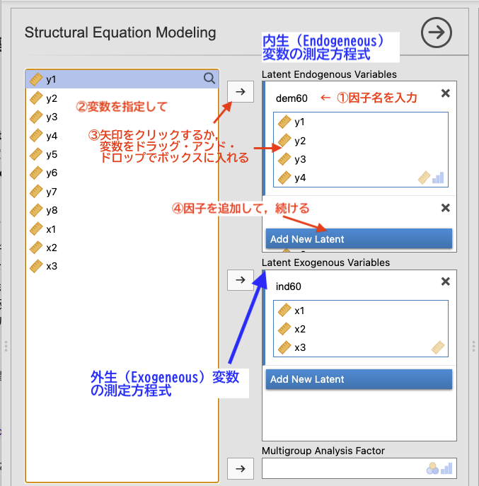

#### **Step 2: 構造モデル (Regressions)の定義**

次に，「因果関係の矢印 (構造方程式)」を設定します。

- **Endogeneous Models** メニューを展開する。
  - 「1960年の民主化指標 (`dem60`)は，1960年の工業化指標 (`ind60`)から影響を受ける」という方程式を定義する。
    - `Endogeneous = dem60` で `drag varible here` となっているボックスをクリックし，**Defined Factors** から `ind60` を選択し，$\rightarrow$ をクリック
  - 「1965年の民主化指標 (`dem65`)は，1960年の民主化指標 (`dem60`)と工業化指標 (`ind60`)から影響を受ける」という方程式を定義する。
    - `Endogeneous = dem65` で `drag varible here` となっているボックスをクリックし，**Defined Factors** から `dem60` を選択し，$\rightarrow$ をクリック
    - `Endogeneous = dem65` で `drag varible here` となっているボックスをクリックし，**Defined Factors** から `ind60` を選択し，$\rightarrow$ をクリック
    - この投入は1つずつ行うこと。2つ同時に入れると dem60 $\times$ ind60 の交互作用も投入されてしまう。交互作用が投入されしまった場合は，交互作用を選択して，$\leftarrow$ をクリックしてモデルから削除する。

Fig.6 構造方程式

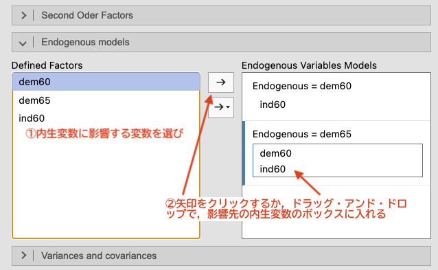

これで，右側の画面にリアルタイムで分析結果が計算されて出力されます！

### 3. lavaan形式 (シンタックス)へのステップアップ

GUIでの操作は手軽ですが，モデルが複雑になってくると何度もメニューをクリックするのが面倒になります。そこで，世界中で広く使われている記述ルールである lavaan 形式を学びましょう。

SEMLjでは，書いた文字をそのままモデルとして解釈させることができます。覚えるべき記号はたったの3つだけです。

| 記号 | 意味 | 読み方・イメージ | 具体例 |  |
| --- | --- | --- | --- | --- |
| `=~` | 測定する (因子を構成する) | 「左の丸」は，「右の四角たち」から成り立つ | `ind60 =~ x1 + x2 + x3` |  |
| `~` | 回帰する (因果の矢印) | 「左の結果」は，「右の原因」から影響を受ける | `dem65 ~ dem60 + ind60` |  |
| `~~` | 相関・残差相関 | 「左」と「右」はお互いに関連している | `x1 ~~ x2` |  |

#### lavaan構文の作成に挑戦

SEMLjの起動メニューで「`SEM (Syntax)`」 を選択します。 入力欄に，先ほどGUIで行った設定を以下の数行のテキストとして直接打ち込んでみましょう (既存のGUIモデルとは別に分析が行われる)。

```r
# 1. 測定モデル (因子分析の部分)
dem60 =~ y1 + y2 + y3 + y4
dem65 =~ y5 + y6 + y7 + y8
ind60 =~ x1 + x2 + x3

# 2. 構造モデル (回帰分析の部分)
dem65 ~ dem60 + ind60
dem60 ~ ind60
```

改行してこの通りに打ち込むだけで，GUIと全く同じ分析が実行されます。 「文字で書いた方が，自分のモデルの全体像が一目でわかってスッキリする」という感覚をぜひ体験してください。